# ProsperLoanData Project

**by Daniel Lee**

## Preliminary Wrangling

```python
# import all packages and set plots to be embedded inline
import numpy as np
import pandas as pd
import matplotlib.pyplot as plt
import seaborn as sb

%matplotlib inline
```

```python
df = pd.read_csv('prosperLoanData.csv')
df.head(5)
```

|  | ListingKey | ListingNumber | ListingCreationDate | CreditGrade | Term | LoanStatus | ClosedDate | BorrowerAPR | BorrowerRate | LenderYield | ... | LP_ServiceFees | LP_CollectionFees | LP_GrossPrincipalLoss | LP_NetPrincipalLoss | LP_NonPrincipalRecoverypayments | PercentFunded | Recommendations | InvestmentFromFriendsCount | InvestmentFromFriendsAmount | Investors |
| --- | --- | --- | --- | --- | --- | --- | --- | --- | --- | --- | --- | --- | --- | --- | --- | --- | --- | --- | --- | --- | --- |
| 0 | 1021339766868145413AB3B | 193129 | 2007-08-26 19:09:29.263000000 | C | 36 | Completed | 2009-08-14 00:00:00 | 0.16516 | 0.1580 | 0.1380 | ... | -133.18 | 0.0 | 0.0 | 0.0 | 0.0 | 1.0 | 0 | 0 | 0.0 | 258 |
| 1 | 10273602499503308B223C1 | 1209647 | 2014-02-27 08:28:07.900000000 | NaN | 36 | Current | NaN | 0.12016 | 0.0920 | 0.0820 | ... | 0.00 | 0.0 | 0.0 | 0.0 | 0.0 | 1.0 | 0 | 0 | 0.0 | 1 |
| 2 | 0EE9337825851032864889A | 81716 | 2007-01-05 15:00:47.090000000 | HR | 36 | Completed | 2009-12-17 00:00:00 | 0.28269 | 0.2750 | 0.2400 | ... | -24.20 | 0.0 | 0.0 | 0.0 | 0.0 | 1.0 | 0 | 0 | 0.0 | 41 |
| 3 | 0EF5356002482715299901A | 658116 | 2012-10-22 11:02:35.010000000 | NaN | 36 | Current | NaN | 0.12528 | 0.0974 | 0.0874 | ... | -108.01 | 0.0 | 0.0 | 0.0 | 0.0 | 1.0 | 0 | 0 | 0.0 | 158 |
| 4 | 0F023589499656230C5E3E2 | 909464 | 2013-09-14 18:38:39.097000000 | NaN | 36 | Current | NaN | 0.24614 | 0.2085 | 0.1985 | ... | -60.27 | 0.0 | 0.0 | 0.0 | 0.0 | 1.0 | 0 | 0 | 0.0 | 20 |

5 rows × 81 columns

```python
df.shape
```

```
(113937, 81)
```

```python
df.info()
```

```
<class 'pandas.core.frame.DataFrame'>
RangeIndex: 113937 entries, 0 to 113936
Data columns (total 81 columns):
ListingKey                             113937 non-null object
ListingNumber                          113937 non-null int64
ListingCreationDate                    113937 non-null object
CreditGrade                            28953 non-null object
Term                                   113937 non-null int64
LoanStatus                             113937 non-null object
ClosedDate                             55089 non-null object
BorrowerAPR                            113912 non-null float64
BorrowerRate                           113937 non-null float64
LenderYield                            113937 non-null float64
EstimatedEffectiveYield                84853 non-null float64
EstimatedLoss                          84853 non-null float64
EstimatedReturn                        84853 non-null float64
ProsperRating (numeric)                84853 non-null float64
ProsperRating (Alpha)                  84853 non-null object
ProsperScore                           84853 non-null float64
ListingCategory (numeric)              113937 non-null int64
BorrowerState                          108422 non-null object
Occupation                             110349 non-null object
EmploymentStatus                       111682 non-null object
EmploymentStatusDuration               106312 non-null float64
IsBorrowerHomeowner                    113937 non-null bool
CurrentlyInGroup                       113937 non-null bool
GroupKey                               13341 non-null object
DateCreditPulled                       113937 non-null object
CreditScoreRangeLower                  113346 non-null float64
CreditScoreRangeUpper                  113346 non-null float64
FirstRecordedCreditLine                113240 non-null object
CurrentCreditLines                     106333 non-null float64
OpenCreditLines                        106333 non-null float64
TotalCreditLinespast7years             113240 non-null float64
OpenRevolvingAccounts                  113937 non-null int64
OpenRevolvingMonthlyPayment            113937 non-null float64
InquiriesLast6Months                   113240 non-null float64
TotalInquiries                         112778 non-null float64
CurrentDelinquencies                   113240 non-null float64
AmountDelinquent                       106315 non-null float64
```

[output cut: 31 more lines]

```
LP_CustomerPayments                    113937 non-null float64
LP_CustomerPrincipalPayments           113937 non-null float64
LP_InterestandFees                     113937 non-null float64
LP_ServiceFees                         113937 non-null float64
LP_CollectionFees                      113937 non-null float64
LP_GrossPrincipalLoss                  113937 non-null float64
LP_NetPrincipalLoss                    113937 non-null float64
LP_NonPrincipalRecoverypayments        113937 non-null float64
PercentFunded                          113937 non-null float64
Recommendations                        113937 non-null int64
InvestmentFromFriendsCount             113937 non-null int64
InvestmentFromFriendsAmount            113937 non-null float64
Investors                              113937 non-null int64
dtypes: bool(3), float64(50), int64(11), object(17)
memory usage: 68.1+ MB
```

## Cleaning dataset

```python
#define interested features in dataset
features = ['ProsperRating (Alpha)','BorrowerAPR','EmploymentStatus',
            'IsBorrowerHomeowner','StatedMonthlyIncome','LoanOriginalAmount',
            'DebtToIncomeRatio','CurrentCreditLines','IncomeVerifiable']
```

```python
loan = df[features]
loan.head(5)
```

|  | ProsperRating (Alpha) | BorrowerAPR | EmploymentStatus | IsBorrowerHomeowner | StatedMonthlyIncome | LoanOriginalAmount | DebtToIncomeRatio | CurrentCreditLines | IncomeVerifiable |
| --- | --- | --- | --- | --- | --- | --- | --- | --- | --- |
| 0 | NaN | 0.16516 | Self-employed | True | 3083.333333 | 9425 | 0.17 | 5.0 | True |
| 1 | A | 0.12016 | Employed | False | 6125.000000 | 10000 | 0.18 | 14.0 | True |
| 2 | NaN | 0.28269 | Not available | False | 2083.333333 | 3001 | 0.06 | NaN | True |
| 3 | A | 0.12528 | Employed | True | 2875.000000 | 10000 | 0.15 | 5.0 | True |
| 4 | D | 0.24614 | Employed | True | 9583.333333 | 15000 | 0.26 | 19.0 | True |

```python
loan.info()
```

```
<class 'pandas.core.frame.DataFrame'>
RangeIndex: 113937 entries, 0 to 113936
Data columns (total 9 columns):
ProsperRating (Alpha)    84853 non-null object
BorrowerAPR              113912 non-null float64
EmploymentStatus         111682 non-null object
IsBorrowerHomeowner      113937 non-null bool
StatedMonthlyIncome      113937 non-null float64
LoanOriginalAmount       113937 non-null int64
DebtToIncomeRatio        105383 non-null float64
CurrentCreditLines       106333 non-null float64
IncomeVerifiable         113937 non-null bool
dtypes: bool(2), float64(4), int64(1), object(2)
memory usage: 6.3+ MB
```

There are missing values in these features: BorrowerAPR, EmploymentStatus, DebtToIncomeRatio, CurrentCreditLines

```python
# Define EmploymentStatus as a category
rate_order = ['HR','E','D','C','B','A','AA']
ordered_loan = pd.api.types.CategoricalDtype(ordered = True, categories = rate_order)
loan.loc[:,'ProsperRating (Alpha)'] = loan['ProsperRating (Alpha)'].astype(ordered_loan, inplace=True)
```

```python
loan['EmploymentStatus'].unique()
```

```
array(['Self-employed', 'Employed', 'Not available', 'Full-time', 'Other',
       nan, 'Not employed', 'Part-time', 'Retired'], dtype=object)
```

```python
#Fill nan value in EmploymentStatus with Other
loan['EmploymentStatus'].fillna(value = 'Other', inplace=True)
loan['EmploymentStatus'].unique()
```

```
array(['Self-employed', 'Employed', 'Not available', 'Full-time', 'Other',
       'Not employed', 'Part-time', 'Retired'], dtype=object)
```

```python
# Define EmploymentStatus as a category
employment_status_dict = ['Other', 'Not employed','Retired','Self-employed', 'Part-time', 'Full-time', 'Employed']
ordered_employment_status = pd.api.types.CategoricalDtype(ordered = True, categories = employment_status_dict)
loan.loc[:,'EmploymentStatus'] = loan['EmploymentStatus'].astype(ordered_employment_status, inplace=True)
```

**Check nan value in numeric features**

```python
print('StatedMonthlyIncome nan values: ',loan['StatedMonthlyIncome'].isnull().sum())
print('LoanOriginalAmount nan values: ',loan['LoanOriginalAmount'].isnull().sum())
print('BorrowerAPR nan values: ',loan['BorrowerAPR'].isnull().sum())
print('DebtToIncomeRatio nan values: ',loan['DebtToIncomeRatio'].isnull().sum())
print('CurrentCreditLines nan values: ',loan['CurrentCreditLines'].isnull().sum())
```

```
StatedMonthlyIncome nan values:  0
LoanOriginalAmount nan values:  0
BorrowerAPR nan values:  25
DebtToIncomeRatio nan values:  8554
CurrentCreditLines nan values:  7604
```

```python
#fill nan value in BorrowerAPR with 0
loan['BorrowerAPR'].fillna(value=0, inplace=True)

#fill nan value in DebtToIncomeRatio with 0
loan['DebtToIncomeRatio'].fillna(value = 0, inplace=True)

#fill nan value in CurrentCreditLines with 0
loan['CurrentCreditLines'].fillna(value = 0, inplace=True)
```

```python
loan.info()
```

```
<class 'pandas.core.frame.DataFrame'>
RangeIndex: 113937 entries, 0 to 113936
Data columns (total 9 columns):
ProsperRating (Alpha)    84853 non-null category
BorrowerAPR              113937 non-null float64
EmploymentStatus         108590 non-null category
IsBorrowerHomeowner      113937 non-null bool
StatedMonthlyIncome      113937 non-null float64
LoanOriginalAmount       113937 non-null int64
DebtToIncomeRatio        113937 non-null float64
CurrentCreditLines       113937 non-null float64
IncomeVerifiable         113937 non-null bool
dtypes: bool(2), category(2), float64(4), int64(1)
memory usage: 4.8 MB
```

```python
loan.describe()
```

|  | BorrowerAPR | StatedMonthlyIncome | LoanOriginalAmount | DebtToIncomeRatio | CurrentCreditLines |
| --- | --- | --- | --- | --- | --- |
| count | 113937.000000 | 1.139370e+05 | 113937.00000 | 113937.000000 | 113937.000000 |
| mean | 0.218780 | 5.608026e+03 | 8337.01385 | 0.255229 | 9.628637 |
| std | 0.080421 | 7.478497e+03 | 6245.80058 | 0.535602 | 5.867722 |
| min | 0.000000 | 0.000000e+00 | 1000.00000 | 0.000000 | 0.000000 |
| 25% | 0.156290 | 3.200333e+03 | 4000.00000 | 0.130000 | 6.000000 |
| 50% | 0.209710 | 4.666667e+03 | 6500.00000 | 0.210000 | 9.000000 |
| 75% | 0.283700 | 6.825000e+03 | 12000.00000 | 0.310000 | 13.000000 |
| max | 0.512290 | 1.750003e+06 | 35000.00000 | 10.010000 | 59.000000 |

### What is the structure of your dataset?

The dataset has 113937 rows and 81 features. This analysis will focus on features that are related to BorrowerAPR.

### What is/are the main feature(s) of interest in your dataset?

Main features in dataset are:

- BorrowerAPR, LoanOriginalAmount, DebtToIncomeRatio, CurrentCreditLines, StatedMonthlyIncome
- LoanStatus, EmploymentStatus, IsBorrowerHomeowner, IncomeVerifiable

### What features in the dataset do you think will help support your investigation into your feature(s) of interest?

StatedMonthlyIncome and DebtToIncomeRatio will have strong correlation with BorrowerAPR. The higher income, the lower BorrwerAPR is. It is the same trend for EmploymentStatus and LoanStatus

## Univariate Exploration

**Let's have a look at distribution of BorrowerAPR**

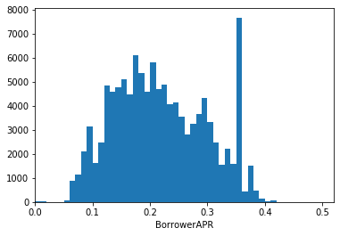

```python
bins = np.arange(0, max(loan['BorrowerAPR'])+0.1, 0.01)
plt.hist(data = loan, x='BorrowerAPR', bins=bins)
plt.xlim(0,0.52)
plt.xlabel('BorrowerAPR')
```

The distribution of BorrowerAPR looks like multimodal. There are three main peaks that we can notice:

- below 0.1
- around 0.2
- around 0.3

Furthermore, there is a sharp peak between 0.35 and 0.36.

**Next up, we're going to look at StatedMonthlyIncome**

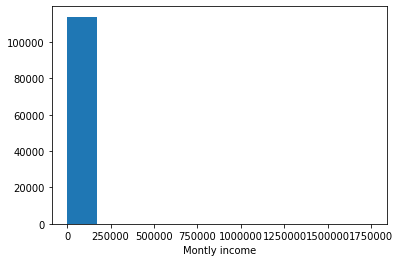

```python
plt.hist(data = loan, x = 'StatedMonthlyIncome')
plt.xlabel('Montly income')
```

From distribution above, it can be clearlt see that there are outliers in this feature. Let's see how many percentage of outlier that are greater than 45000 and we'll remove outliers if there is a small percentage of outliers in dataset

```python
nb_outliers = loan[loan['StatedMonthlyIncome']>45000].shape[0]
print(f'Number of outlier that are above 45k: {nb_outliers}')
print(f'Percentage of outlier that are above 45k: {round((nb_outliers/loan.shape[0])*100,3)}%')
```

```
Number of outlier that are above 45k: 109
Percentage of outlier that are above 45k: 0.096%
```

```python
# we will remove those with monthly income above 50k
loan_outliers = loan[loan['StatedMonthlyIncome']<45000]
loan_outliers.reset_index(drop=True, inplace=True)
loan_outliers.shape
```

```
(113825, 9)
```

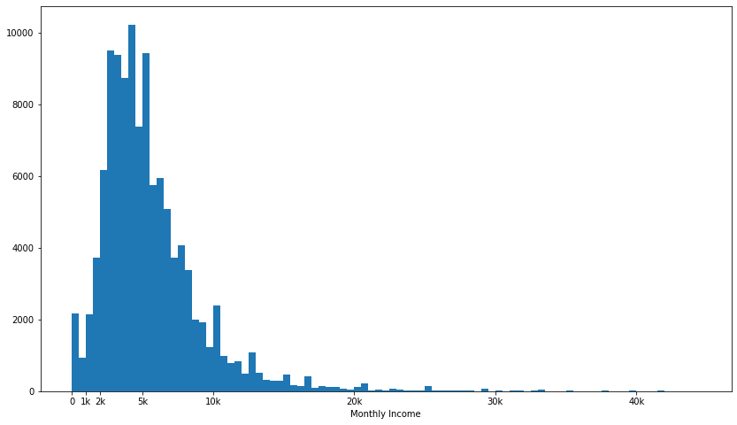

```python
plt.figure(figsize=(14,8))
bins = np.arange(0, loan_outliers['StatedMonthlyIncome'].max()+100, 500)
plt.hist(data = loan_outliers , x ='StatedMonthlyIncome', bins = bins)
plt.xticks([0, 1e3, 2e3, 5e3, 1e4, 2e4, 3e4, 4e4], [0, '1k', '2k', '5k', '10k', '20k', '30k', '40k'])
plt.xlabel('Monthly Income')
```

StatedMonthlyIncome is unimodal with one peak around 5k. The distribution is right skewed. Most of people have monthly income less than 20k.

**Next up, we're going to look at LoanOriginalAmount**

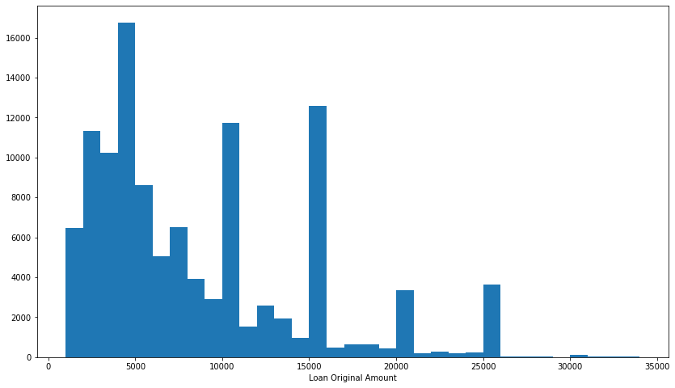

```python
plt.figure(figsize=(14,8))
bins = np.arange(1000,35000, 1000)
plt.hist(data = loan, x = 'LoanOriginalAmount', bins=bins)
plt.xlabel('Loan Original Amount')
```

```python
loan_income =  loan[['LoanOriginalAmount','StatedMonthlyIncome']]
loan_income.query("StatedMonthlyIncome>100000")
```

|  | LoanOriginalAmount | StatedMonthlyIncome |
| --- | --- | --- |
| 8066 | 2000 | 4.166667e+05 |
| 8870 | 12500 | 2.083333e+05 |
| 17411 | 7500 | 4.833333e+05 |
| 35218 | 1000 | 1.083333e+05 |
| 45028 | 4000 | 1.500000e+05 |
| 53014 | 4000 | 6.185478e+05 |
| 53167 | 4000 | 1.750003e+06 |
| 56867 | 25000 | 1.850818e+05 |
| 57133 | 4000 | 4.666667e+05 |
| 59298 | 15000 | 1.208333e+05 |
| 63925 | 2000 | 1.404167e+05 |
| 78431 | 5000 | 1.033341e+05 |
| 80075 | 25000 | 1.583333e+05 |
| 82831 | 4000 | 2.500000e+05 |
| 83697 | 5000 | 1.850818e+05 |
| 111265 | 12765 | 1.087500e+05 |
| 113270 | 2000 | 3.944000e+05 |

The distribution of loan original amount is multimodal that people often make loans with amount of 5000, 10000 and 15000. People who have higher montly income often have small loan

**DebtToIncomeRatio**

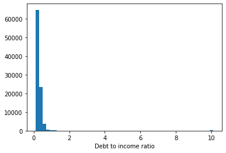

```python
bins = np.arange(0.1, loan['DebtToIncomeRatio'].max()+0.1, 0.2)
plt.hist(data = loan, x='DebtToIncomeRatio', bins = bins)
plt.xlabel('Debt to income ratio')
```

We can see that the distribution is highly right skewed which means it contains outliers. We are going to divide this variable into two graph: one with debt<income (the ratio is less than 1) and one with debt>income (ratio is greater than 1)  
Now we are going to look at those have debt less than income  
**Debt<Income**

```python
nb = loan[loan['DebtToIncomeRatio']>1].shape[0]
percent = round((nb/loan.shape[0]),3)*100
loan_ratio = loan[loan['DebtToIncomeRatio']<1].reset_index(drop=True)
```

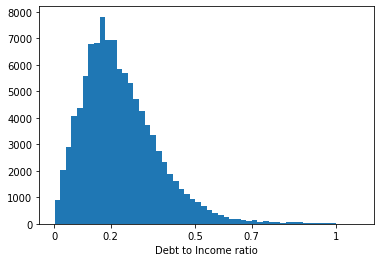

```python
bins = np.arange(0.001, loan_ratio['DebtToIncomeRatio'].max()+0.1, 0.02)
plt.hist(data = loan_ratio, x='DebtToIncomeRatio', bins=bins)
plt.xticks([0, 0.2, 0.5,0.7,1], [0, 0.2, 0.5, 0.7, 1])
plt.xlabel('Debt to Income ratio')
```

this is a unimodal distribution that the amount of debt less than income is around 0.2

Its interesting to see that people have debt greater than income  
**Debt>Income**

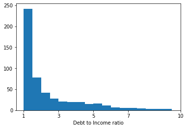

```python
loan_debt = loan[loan['DebtToIncomeRatio']>1].reset_index(drop=True)
bins = np.arange(1, 10, 0.5)
plt.hist(data = loan_debt, x='DebtToIncomeRatio', bins=bins)
plt.xticks([1, 3, 5, 7, 10],[1, 3, 5, 7, 10] )
plt.xlabel('Debt to Income ratio')
```

**Current Credit Lines**

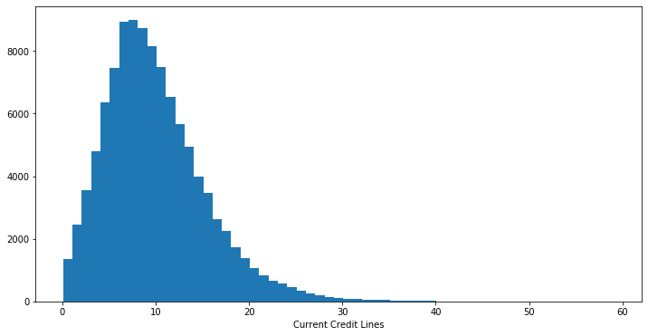

```python
plt.figure(figsize = (12,6))
bins = np.arange(0.1, 60, 1)
plt.hist(data = loan, x = 'CurrentCreditLines', bins = bins)
plt.xlabel('Current Credit Lines')
```

### Categorical features

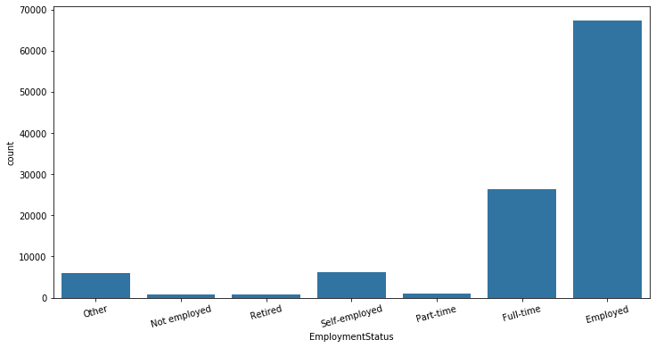

```python
plt.figure(figsize=(12,6))
default_color = sb.color_palette()[0]
sb.countplot(data= loan, x= 'EmploymentStatus', color = default_color)
plt.xticks(rotation=15)
```

From the graph, we can clearly see that most of people are employed and have a full-time position

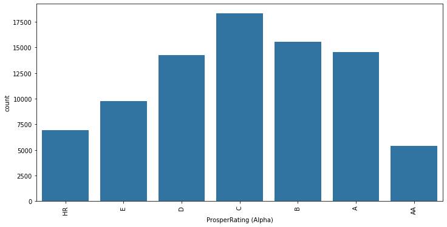

```python
plt.figure(figsize=(12,6))
default_color = sb.color_palette()[0]
sb.countplot(data= loan, x= 'ProsperRating (Alpha)', color = default_color)
plt.xticks(rotation=90)
```

Most of people have prosper rating ranging from D to A

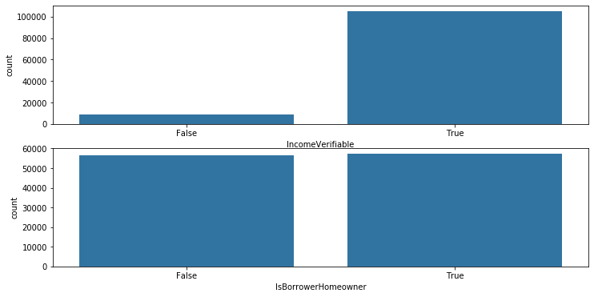

```python
fig, ax = plt.subplots(nrows = 2, figsize=(12,6))
default_color = sb.color_palette()[0]
sb.countplot(data=loan, x='IncomeVerifiable', ax = ax[0], color = default_color)
sb.countplot(data=loan, x='IsBorrowerHomeowner', ax = ax[1], color = default_color)
```

The number of people owning a house is equal to those don't have. Most of borrowers account in this dataset is verifiable

### Discuss the distribution(s) of your variable(s) of interest. Were there any unusual points? Did you need to perform any transformations?

The distribution of BorrowerAPR looks like multimodal. There are three main peaks that we can notice: below 0.1 around 0.2 around 0.3 Furthermore, there is a sharp peak between 0.35 and 0.36. There is no unusual points so no need to perform any transformation

### Of the features you investigated, were there any unusual distributions? Did you perform any operations on the data to tidy, adjust, or change the form of the data? If so, why did you do this?

The distributions of stated monthly income is highly right screwed. Most stated monthly incomes are less than 20k, but some of them are incredibly high, like greater than 100k. Surprisingly, most of borrowers with greater than 100k monthly income often have small loan. Most of people are employed or have a full-time job, which prosper rating are in range from D to A.

There is no need to perform any transformations.

## Bivariate Exploration

```python
numeric_vars = ['BorrowerAPR', 'StatedMonthlyIncome', 'LoanOriginalAmount', 'DebtToIncomeRatio', 'CurrentCreditLines']
categorical_vars = ['ProsperRating (Alpha)', 'EmploymentStatus']
```

To start off with, I want to look at the pairwise correlations present between features in the data.

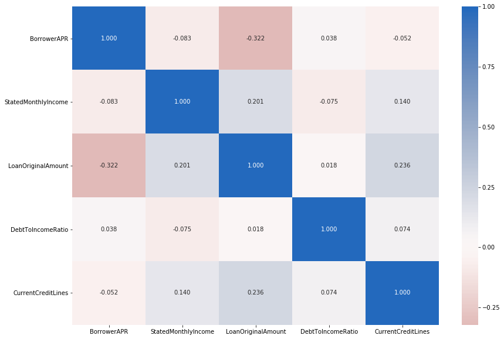

```python
# correlation plot
plt.figure(figsize = [14, 10])
sb.heatmap(loan[numeric_vars].corr(), annot = True, fmt = '.3f',
           cmap = 'vlag_r', center = 0)
plt.show()
```

I want to see more how BorrowerAPR and LoanOriginalAmount are correlated.

```python
loan_sub = loan.query("StatedMonthlyIncome<40000")
```

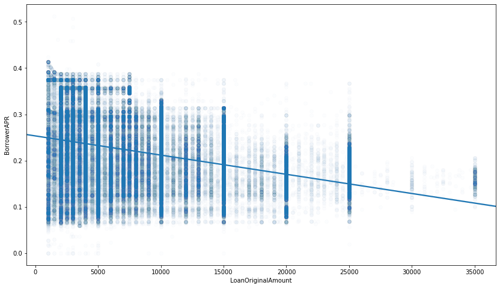

```python
plt.figure(figsize= (14,8))
sb.regplot(data = loan, x='LoanOriginalAmount', y='BorrowerAPR', scatter_kws={'alpha':0.01})
```

The plot shows that borrowerAPR have a negative correlation with LoanOriginalAmount

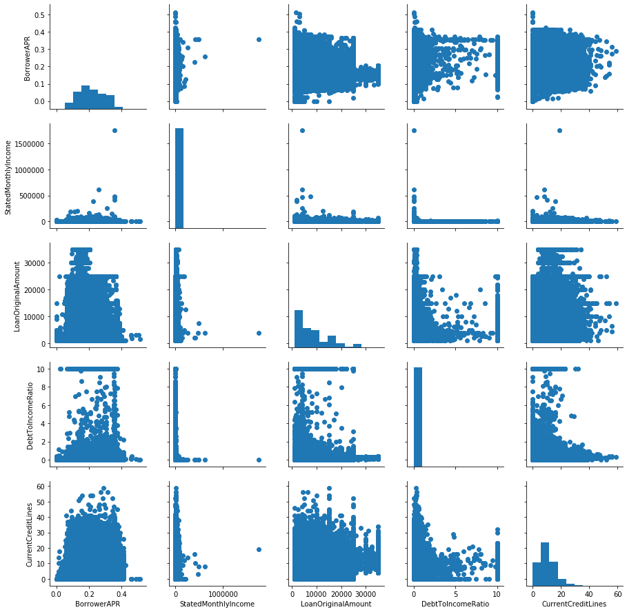

```python
g = sb.PairGrid(data= loan, vars = numeric_vars)
g = g.map_diag(plt.hist, bins = 10);
g.map_offdiag(plt.scatter)
```

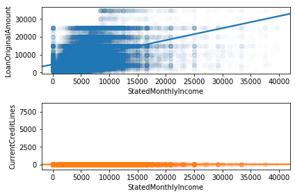

```python
plt.figure(figsize= (20,10))
fig, ax = plt.subplots(nrows = 2, ncols = 1)

#subplot 1: StatedMonthlyIncome vs LoanOriginalAmount
sb.regplot(data = loan_sub, x='StatedMonthlyIncome', y='LoanOriginalAmount', scatter_kws={'alpha':0.01}, ax=ax[0])

#subplot 2: StatedMonthlyIncome vs CurrentCreditLines
sb.regplot(data = loan_sub, x='StatedMonthlyIncome', y='CurrentCreditLines', scatter_kws={'alpha':0.01}, ax = ax[1])

fig.tight_layout()
```

Furthermore, StatedMonthlyIncome have a positive correlation with CurrentCreditLines and LoanOriginalAmount, which means the more monthly income they have, the more loan or credit lines they can lend.

Let's move on to looking at how BorrowerAPR, StatedMonthlyIncome, LoanOriginalAmount correlate with the categorical variables.

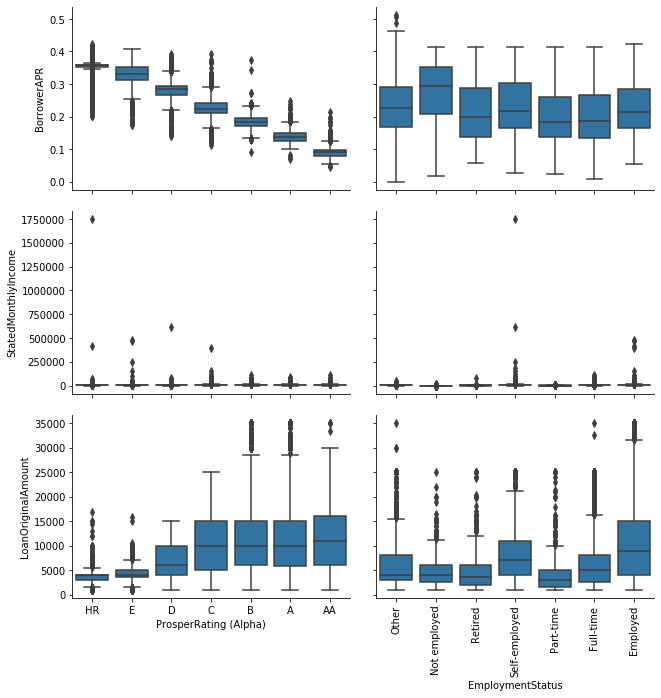

```python
# plot matrix of numeric features against categorical features.
def boxgrid(x, y, **kwargs):
    """ Quick hack for creating box plots with seaborn's PairGrid. """
    default_color = sb.color_palette()[0]
    sb.boxplot(x, y, color = default_color)
plt.figure(figsize = [14, 10])
g = sb.PairGrid(data = loan, y_vars = ['BorrowerAPR', 'StatedMonthlyIncome', 'LoanOriginalAmount'], x_vars = categorical_vars,
                height = 3, aspect = 1.5)
g.map(boxgrid)
plt.xticks(rotation=90)
```

For StatedMonthlyIncome, there are lots of outliers in dataset. So it is not cleared displayed in the graph. We'll remove outliers and get more insight these data

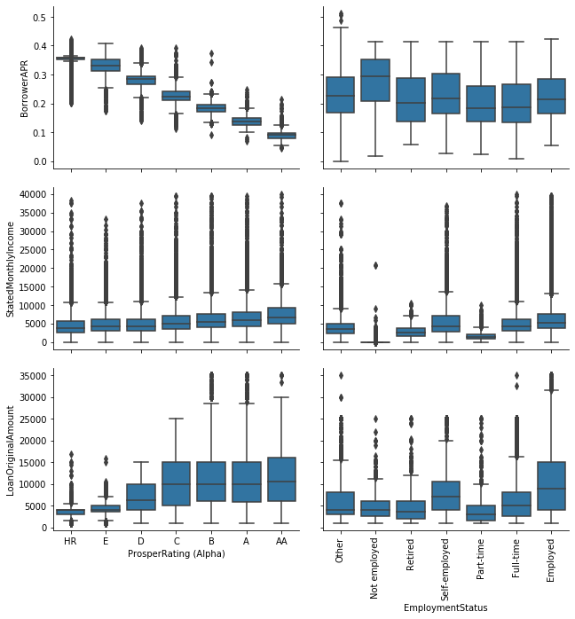

```python
# plot matrix of numeric features against categorical features.
def boxgrid(x, y, **kwargs):
    """ Quick hack for creating box plots with seaborn's PairGrid. """
    default_color = sb.color_palette()[0]
    sb.boxplot(x, y, color = default_color)
plt.figure(figsize = [14, 10])
g = sb.PairGrid(data = loan_sub, y_vars = ['BorrowerAPR', 'StatedMonthlyIncome', 'LoanOriginalAmount'], x_vars = categorical_vars,
                height = 3, aspect = 1.5)
g.map(boxgrid)
plt.xticks(rotation=90)
```

From the graph above, we can see that BorrowerAPR tend to be decreased when people have high rating. It makes sense that the amount of money they earn represents their ratings, the higher their monthly income, the higher their ratings. Those have rating from C to AA tend to lend more money than the rest.

Not Employed, self-employed and retired people will have higher borrowerAPR than those have part-time or full-time jobs. Surprisingly, although those have a jobs have higher income, they tend to lend more money than the rest.

Finally, let's look at relationships between the two categorical features.

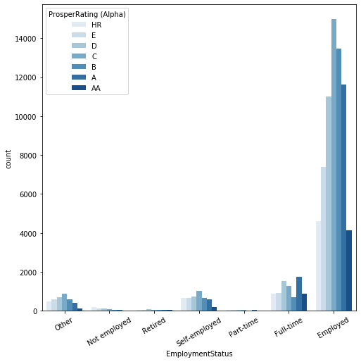

```python
plt.figure(figsize = (8,8))
sb.countplot(data = loan_sub, x = 'EmploymentStatus', hue = 'ProsperRating (Alpha)', palette = 'Blues')
plt.xticks(rotation = 30)
```

We do not have enough data to show Not employed, Part-time, Retired on EmploymentStatus variable. Most of employed people tend to be rated rather than the rest.

### Talk about some of the relationships you observed in this part of the investigation. How did the feature(s) of interest vary with other features in the dataset?

The borrower APR is negatively associated with the loan original amount, which mean the more the loan amount, the lower the APR. It also shows that at different size of the loan amount, the APR has a large range, but the range of APR decrease with the increase of loan amount. The Prosper rating also has a strong effect on the borrower APR, which decreases with the better rating.

### Did you observe any interesting relationships between the other features (not the main feature(s) of interest)?

The loan original amount is positively correlated with the stated monthly income, it makes sense since borrowers with more monthly income could loan more money. It also shows that borrowers with better rating also have larger monthly income and loan amount.

## Multivariate Exploration

In this part, we'll focus on how the categorical variables (Employment Status and Prosper Rating) play into the relationship between borrower APR and loan original amount.

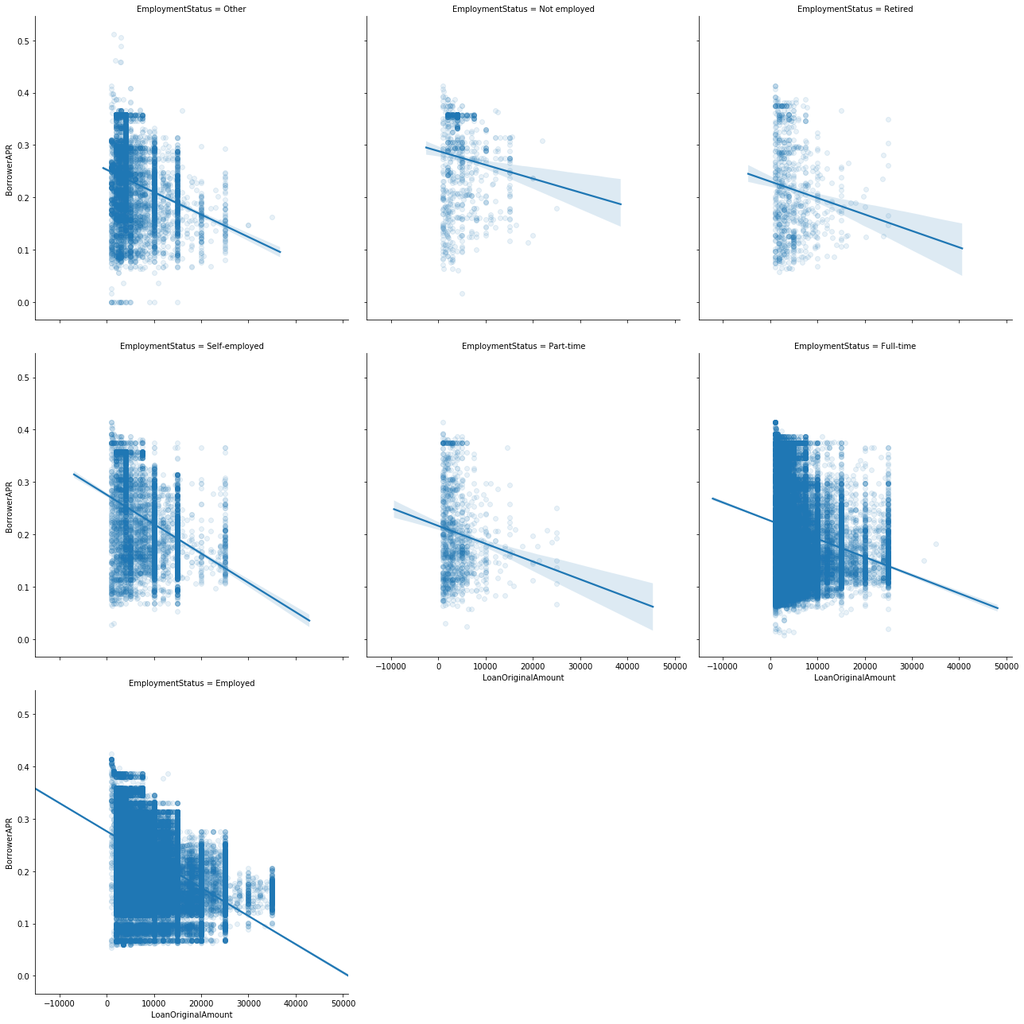

```python
#Employment Status effect on the relationship between BorrowerAPR and LoanOriginalAmount
g = sb.FacetGrid(data = loan_sub, height = 6, col = 'EmploymentStatus', col_wrap=3)
g.map(sb.regplot, 'LoanOriginalAmount', 'BorrowerAPR', x_jitter=0.04, scatter_kws={'alpha':0.1})
```

There is no signicant effect of EmploymentStatus on the relationship between BorrowerAPR and LoanOriginalAmount. The higher amount they can lend, the lower anual per rate.

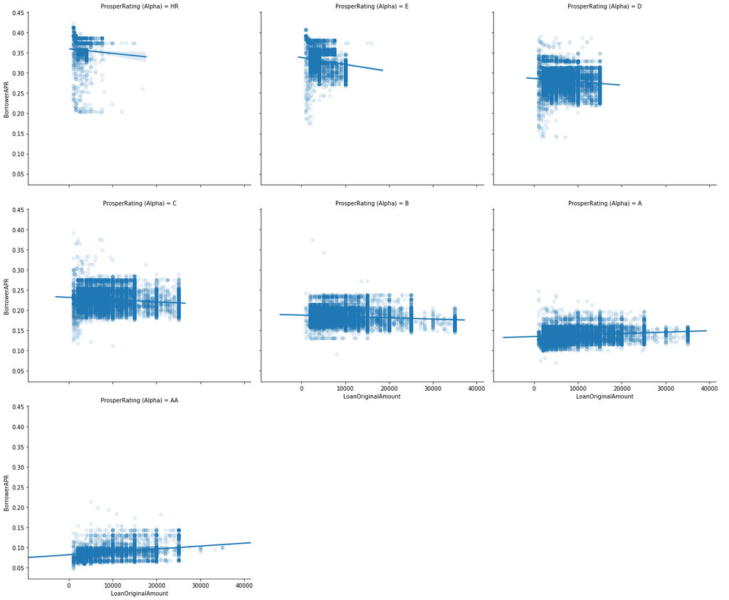

```python
# Prosper rating effect on relationship of APR and loan amount
g=sb.FacetGrid(data=loan_sub, aspect=1.2, height=5, col='ProsperRating (Alpha)', col_wrap=3)
g.map(sb.regplot, 'LoanOriginalAmount', 'BorrowerAPR', x_jitter=0.04, scatter_kws={'alpha':0.1});
g.add_legend()
```

The loan amount increases with better rating. The borrower APR decreases with better rating. Interestingly, the relationship between borrower APR and loan amount turns from negative to slightly positive when the Prosper ratings are increased from HR to A or better. This may because people with A or AA ratings tend to borrow more money, increasting APR could prevent them borrow even more and maximize the profit. But people with lower ratings tend to borrow less money, decreasing APR could encourage them to borrow more.

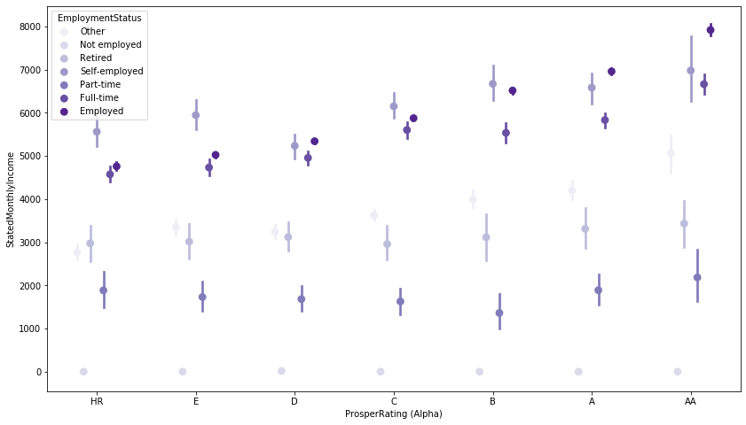

```python
plt.figure(figsize=(14,8))
sb.pointplot(data = loan_sub, x = 'ProsperRating (Alpha)', y = 'StatedMonthlyIncome', hue = 'EmploymentStatus',
           palette = 'Purples', linestyles = '', dodge = 0.4)
```

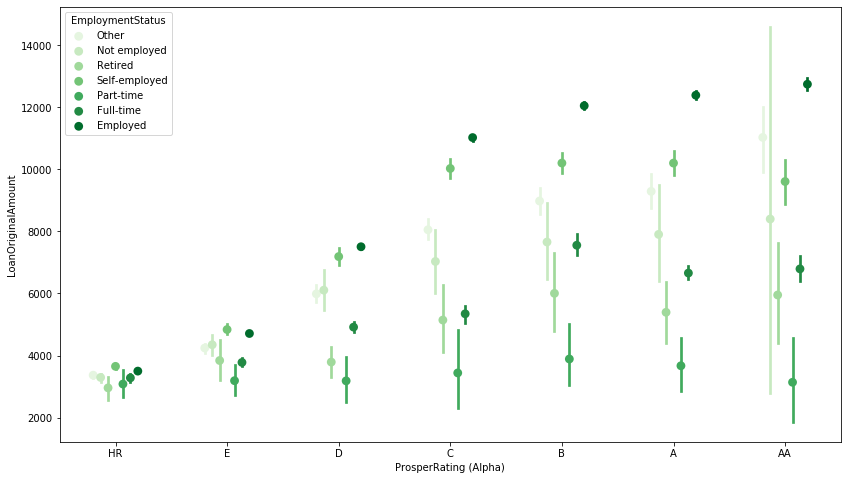

```python
plt.figure(figsize=(14,8))
sb.pointplot(data = loan_sub, x = 'ProsperRating (Alpha)', y = 'LoanOriginalAmount', hue = 'EmploymentStatus',
           palette = 'Greens', linestyles = '', dodge = 0.4)
```

Employed people could be able to lend with high amount of money only for those have rating from C to AA

### Talk about some of the relationships you observed in this part of the investigation. Were there features that strengthened each other in terms of looking at your feature(s) of interest?

I extended my investigation of borrower APR against loan amount by looking at the impact of the Prosper rating. The multivariate exploration showed that the relationship between borrower APR and loan amount turns from negative to slightly positive when the Prosper ratings increased from HR to AA.